# Introduction to templatesIpea (R)

The [**templatesIpea**](https://github.com/ipea-datalab/templatesIpea) is a computational package designed to facilitate the standardization of colors and graphic formatting for text submissions for discussion (TD) and articles for the journal of the Institute of Applied Economic Research (IPEA). This package provides users with tools and functions that simplify the process of applying consistent color schemes and graphic styles in their work, ensuring conformity to the requirements and guidelines of the IPEA journal. By using **templatesIpea**, users can easily achieve visually appealing and professionally formatted text submissions for IPEA. (see detailed information below).. This vignette presents a quick intro to **templatesIpea**.

## Installation

You can install templatesIpea from CRAN or the development version to use the latest features.

```r
# From CRAN
install.packages("templatesIpea")

# Development version
utils::remove.packages('templatesIpea')
devtools::install_github("ipea-datalab/templatesIpea", subdir = "r-package")
```

Now let’s load the libraries we’ll use in this vignette.

```r
library(templatesIpea)
library(ggplot2)
library(dplyr)
library(abjData)
```

## General usage

### Available data sets

```r
# Available data sets
head(ipea_palette(palette = 'ipea1'))
```

```
#> ipea_main7 ipea_main6 ipea_main5 ipea_main4 ipea_main3 ipea_main2
#>  "#40c7f4"  "#9CD2EB"  "#7696AE"  "#2F6280"  "#063754"  "#006EAB"
```

The syntax of all *templatesIpea* functions operate one the same logic, so the code becomes intuitive for the user. Here are a few examples.

Scale Continuous

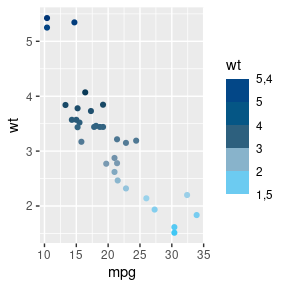

```r
# Load the mtcars dataset
data("mtcars")

# Create a scatter plot with 'mpg' on the x-axis, 'wt' on the y-axis, and color-coded by 'wt'
# Use the 'scale_color_continuous_ipea()' function to apply the IPEA continuous color scale
ggplot() +
  geom_point(data = mtcars, aes(x = mpg, y = wt, color = wt)) +
  scale_color_continuous_ipea()
```

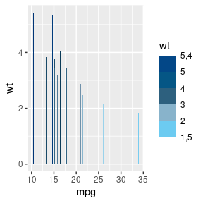

```r
# Create a scatter plot with 'mpg' on the x-axis, 'wt' on the y-axis, and filled by 'wt'
# Use the 'scale_fill_continuous_ipea()' function to apply the IPEA continuous fill scale
ggplot(data = mtcars, aes(x = mpg, y = wt, fill = wt)) +
  geom_bar(stat="identity", position=position_dodge()) +
  scale_fill_continuous_ipea()
```

Scale Discrete

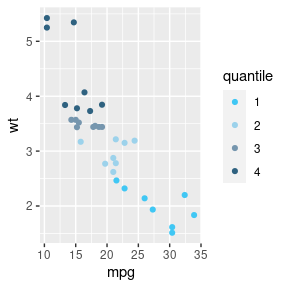

```r
# Load the mtcars dataset
data("mtcars")

# Add a new variable 'quantile' to mtcars based on the weight 'wt' values
# The 'quantile' variable is created by dividing the weight values into quantiles
# The 'type' argument determines the method used to calculate quantiles
# The 'include' argument determines whether the intervals are left-closed and right-open or closed
# The 'labels' argument is set to FALSE to keep the quantile values as numeric
mtcars <- mtcars %>%
  mutate(
    quantile = cut(x = wt, breaks = quantile(wt, probs = 0:4/4),
                   type = c('quantile','(i-1)/(n-1)','i/(n+1)','i/n'), include = T, labels = F),
    quantile = as.character(quantile)
  )

# Create a scatter plot with 'mpg' on the x-axis, 'wt' on the y-axis, and color-coded by 'quantile'
# Use the 'scale_colour_discrete_ipea()' function to apply the IPEA discrete color scale
ggplot(data = mtcars, aes(x = mpg, y = wt, color = quantile)) +
  geom_point() +
  scale_colour_discrete_ipea()
```

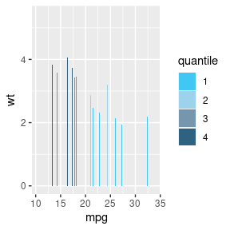

```r
# Create a scatter plot with 'mpg' on the x-axis, 'wt' on the y-axis, and filled by 'quantile'
# Use the 'scale_fill_discrete_ipea()' function to apply the IPEA discrete fill scale
ggplot(data = mtcars, aes(x = mpg, y = wt, fill = quantile)) +
  geom_bar(stat="identity", position=position_dodge()) +
  scale_fill_discrete_ipea()
```

There is also a unique function that from the arguments it is possible to choose whether the scale will be continuous or discrete

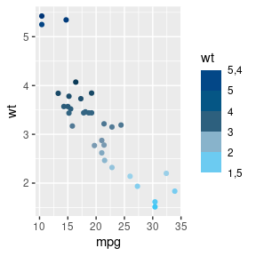

```r
# Load the mtcars dataset
data("mtcars")

# Add a new variable 'quantile' to mtcars dataframe by cutting the 'wt' variable into quantile intervals
mtcars <- mtcars %>%
  mutate(
    quantile = cut(
      x = wt,
      breaks = quantile(wt, probs = 0:4/4),
      type = c('quantile', '(i-1)/(n-1)', 'i/(n+1)', 'i/n'),
      include = TRUE,
      labels = FALSE
    ),
    quantile = as.character(quantile)
  )

# Create a continuous scatter plot with 'mpg' on the x-axis, 'wt' on the y-axis, and color-coded by 'wt'
# Use the 'scale_ipea()' function to apply the IPEA continuous color scale
ggplot(data = mtcars, aes(x = mpg, y = wt, color = wt)) +
  geom_point() +
  scale_ipea(type = "continuous", style = "color")
```

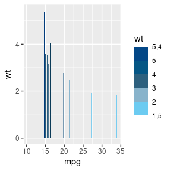

```r
# Create a continuous scatter plot with 'mpg' on the x-axis, 'wt' on the y-axis, and filled by 'wt'
# Use the 'scale_ipea()' function to apply the IPEA continuous fill scale
ggplot(data = mtcars, aes(x = mpg, y = wt, fill = wt)) +
  geom_bar(stat="identity", position=position_dodge()) +
  scale_ipea(type = "continuous", style = "fill")
```

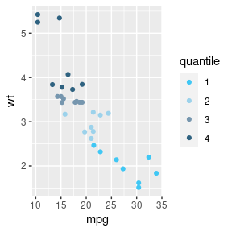

```r
# Create a discrete scatter plot with 'mpg' on the x-axis, 'wt' on the y-axis, and color-coded by 'quantile'
# Use the 'scale_ipea()' function to apply the IPEA discrete color scale
ggplot(data = mtcars, aes(x = mpg, y = wt, color = quantile)) +
  geom_point() +
  scale_ipea(type = "discrete", style = "color")
```

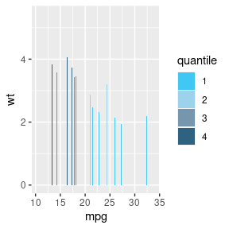

```r
# Create a discrete scatter plot with 'mpg' on the x-axis, 'wt' on the y-axis, and filled by 'quantile'
# Use the 'scale_ipea()' function to apply the IPEA discrete fill scale
ggplot(data = mtcars, aes(x = mpg, y = wt, fill = quantile)) +
  geom_bar(stat="identity", position=position_dodge()) +
  scale_ipea(type = "discrete", style = "fill")
```

## Change theme and text

The next step is to combine the *templatesIpea* package with other data sets to create thematic graphs In this example, we will be using data from the (Atlas of Human Development (by Ipea/FJP and UNPD) to create a graphs showing the variation of Life Expectancy at birth across Brasil countriy.

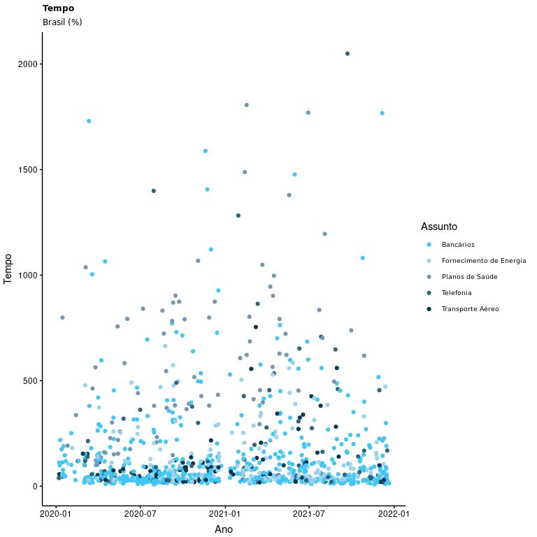

```r
# Load the 'consumo' dataset from the 'abjData' package
cons = abjData::consumo

# Create a simple scatter plot with 'dec_date' on the x-axis, 'tempo' on the y-axis, color-coded by 'assunto', and grouped by 'assunto'
ggplot(data = cons, aes(x = dec_date, y = tempo, color = assunto, group = assunto)) +
  # Use the 'geom_point()' function to add points to the plot
  geom_point() +
  # Set the x-axis label using 'xlab()'
  xlab('Ano') +
  # Set the y-axis label using 'ylab()'
  ylab('Tempo') +
  # Set the plot title and subtitle using 'ggtitle()'
  ggtitle(label = "Tempo", subtitle = "Brasil (%)") +
  # Set the color legend label using 'labs()'
  labs(color = "Assunto") +
  # Apply the IPEA theme using 'theme_ipea()'
  theme_ipea(legend.position = "right") +
  # Use the 'scale_color_discrete_ipea()' function to apply the IPEA discrete color scale
  scale_color_discrete_ipea()
```

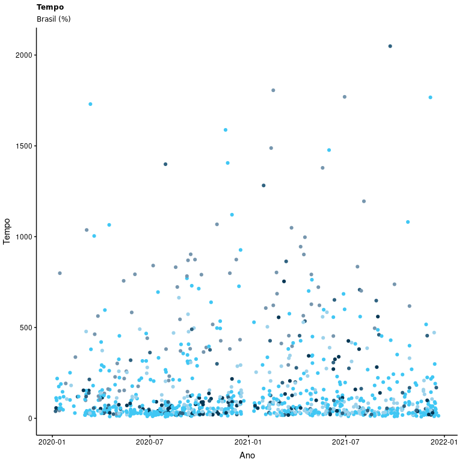

```r
# Create a simple scatter plot with 'dec_date' on the x-axis, 'tempo' on the y-axis, color-coded by 'assunto', and grouped by 'assunto'
ggplot(data = cons, aes(x = dec_date, y = tempo, color = assunto, group = assunto)) +
  # Use the 'geom_point()' function to add points to the plot
  geom_point() +
  # Set the x-axis label using 'xlab()'
  xlab('Ano') +
  # Set the y-axis label using 'ylab()'
  ylab('Tempo') +
  # Set the plot title and subtitle using 'ggtitle()'
  ggtitle(label = "Tempo", subtitle = "Brasil (%)") +
  # Apply the IPEA theme using 'theme_ipea()'
  # Hide the legend using 'legend.position = "none"'
  theme_ipea(legend.position = "none") +
  # Use the 'scale_color_discrete_ipea()' function to apply the IPEA discrete color scale
  scale_color_discrete_ipea()
```

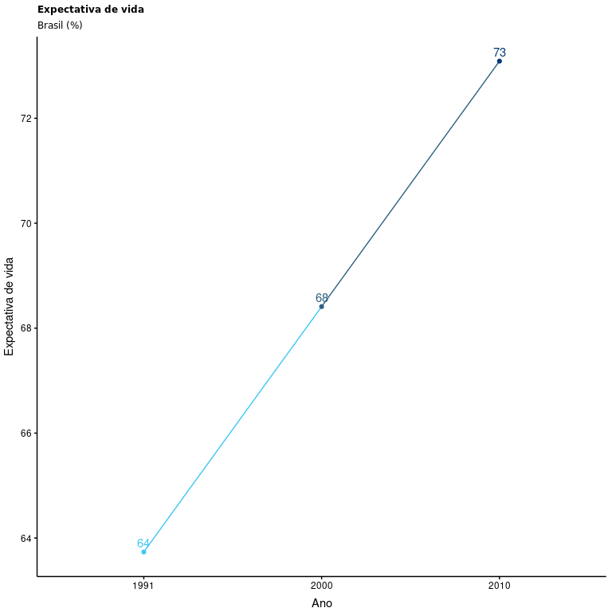

```r
# Calculate the mean values of 'espvida' and 'rdpc' grouped by 'ano' using the 'pnud_muni' dataset
graph <- abjData::pnud_muni %>%
  group_by(ano) %>%
  dplyr::summarise(espvida = mean(espvida),
                   rdpc = mean(rdpc))

# Create a line plot with 'ano' on the x-axis, 'espvida' on the y-axis, color-coded by 'espvida', and grouped by a single group
ggplot(data = graph, aes(x = as.character(ano), y = espvida, color = espvida, group = 1)) +
  # Add a line to the plot using 'geom_line()'
  geom_line() +
  # Add points to the plot using 'geom_point()'
  geom_point() +
  # Set the x-axis label using 'xlab()'
  xlab('Ano') +
  # Set the y-axis label using 'ylab()'
  ylab('Expectativa de vida') +
  # Add a custom text label for 'espvida' using 'insert_text()'
  insert_text(label = "espvida", decimals = 0) +
  # Apply a custom format to the y-axis labels using 'scale_y_continuous()'
  scale_y_continuous(labels = scales::label_comma(decimal.mark = ",", big.mark = ".")) +
  # Set the plot title and subtitle using 'ggtitle()'
  ggtitle(label = "Expectativa de vida", subtitle = "Brasil (%)") +
  # Apply the IPEA continuous color scale using 'scale_color_continuous_ipea()'
  scale_color_continuous_ipea() +
  # Apply the IPEA theme using 'theme_ipea()'
  theme_ipea(legend.position = "none")
```

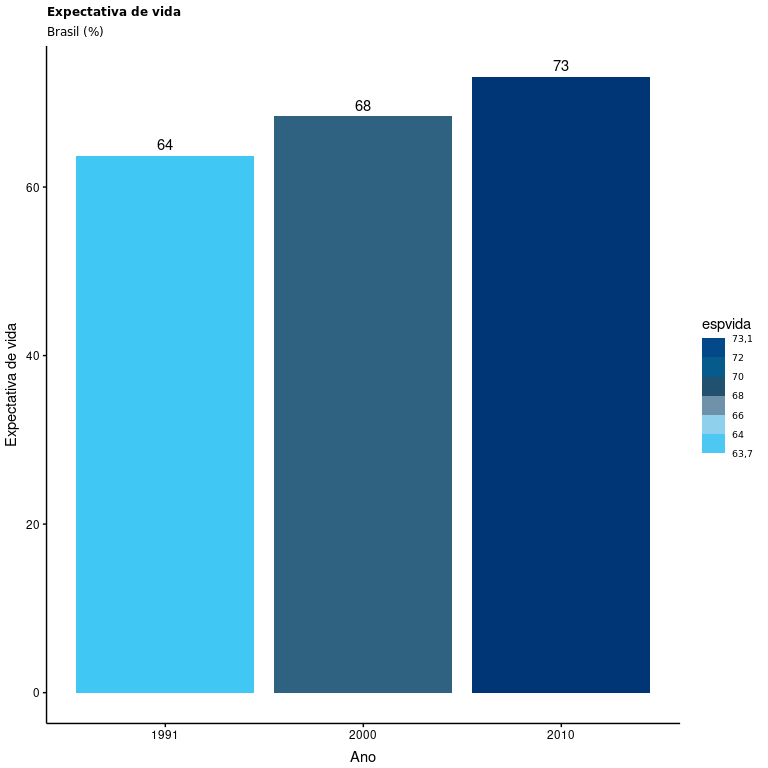

```r
# Calculate the mean values of 'espvida' and 'rdpc' grouped by 'ano' using the 'pnud_muni' dataset
graph <- abjData::pnud_muni %>%
  group_by(ano) %>%
  dplyr::summarise(espvida = mean(espvida),
                   rdpc = mean(rdpc))

# Create a bar plot with 'ano' on the x-axis, 'espvida' on the y-axis, and color-filled by 'espvida'
ggplot(data = graph, aes(x = as.character(ano), y = espvida, fill = espvida)) +
  # Add bars to the plot using 'geom_bar(stat = "identity")'
  geom_bar(stat = "identity") +
  # Set the x-axis label using 'xlab()'
  xlab('Ano') +
  # Set the y-axis label using 'ylab()'
  ylab('Expectativa de vida') +
  # Add a custom text label for 'espvida' using 'insert_text()'
  insert_text(label = "espvida", decimals = 0) +
  # Apply a custom format to the y-axis labels using 'scale_y_continuous()'
  scale_y_continuous(labels = scales::label_comma(decimal.mark = ",", big.mark = ".")) +
  # Set the plot title and subtitle using 'ggtitle()'
  ggtitle(label = "Expectativa de vida", subtitle = "Brasil (%)") +
  # Apply the IPEA theme using 'theme_ipea()'
  theme_ipea() +
  # Apply the IPEA continuous color scale to the fill using 'scale_fill_continuous_ipea()'
  scale_fill_continuous_ipea()
```

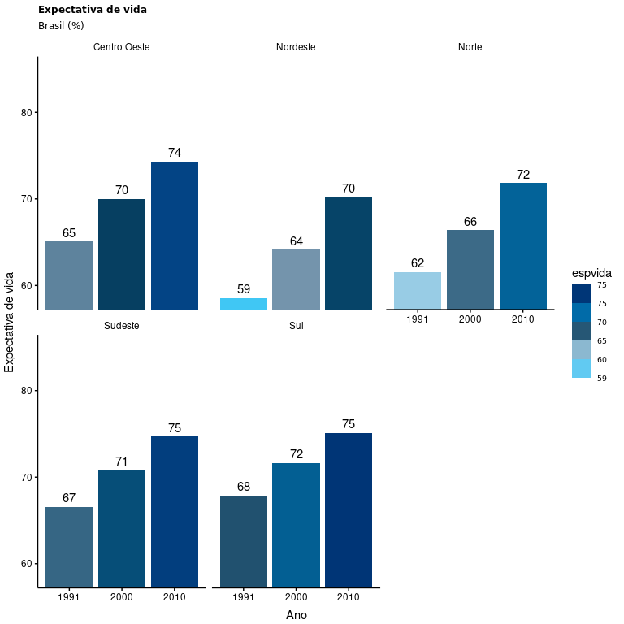

```r
# Calculate the mean values of 'espvida' and 'rdpc' grouped by 'regn' and 'ano' using the 'pnud_muni' dataset
graph <- abjData::pnud_muni %>%
  mutate(regn = substr(uf, 1, 1),  # Extract the first character of 'uf' and assign it to 'regn'
         regn = case_when(regn == "1" ~ "Norte",  # Assign region names based on 'regn' values
                          regn == "2" ~ "Nordeste",
                          regn == "3" ~ "Sudeste",
                          regn == "4" ~ "Sul",
                          regn == "5" ~ "Centro Oeste",
                          TRUE ~ regn)) %>%
  group_by(regn, ano) %>%
  dplyr::summarise(espvida = mean(espvida),  # Calculate the mean of 'espvida' within each 'regn' and 'ano'
                   rdpc = mean(rdpc))  # Calculate the mean of 'rdpc' within each 'regn' and 'ano'


# Option 1 for facet  title color
ggplot(data = graph, aes(x = as.character(ano), y = espvida, fill = espvida)) +
  # Create a bar plot with 'ano' on x-axis, 'espvida' on y-axis, and 'espvida' for fill
  geom_bar(stat = "identity") +
  # Set the x-axis label
  xlab('Ano') +
  # Set the y-axis label
  ylab('Expectativa de vida') +
  # Add value labels to the plot
  insert_text(label = "espvida", decimals = 0) +
  # Create separate panels for each 'regn'
  facet_wrap(. ~ regn) +
  # Format y-axis labels
  scale_y_continuous(labels = scales::label_comma(decimal.mark = ",", big.mark = ".")) +
   # Set the plot title and subtitle
  ggtitle(label = "Expectativa de vida", subtitle = "Brasil (%)") +
  # Apply the IPEA theme with no box around the plot
  theme_ipea(box_option = 0) +
  # Apply the IPEA continuous fill color scale
  scale_fill_continuous_ipea() +
  # Set the y-axis limits
  coord_cartesian(ylim = c(min(graph$espvida), max(graph$espvida) + 10))
```

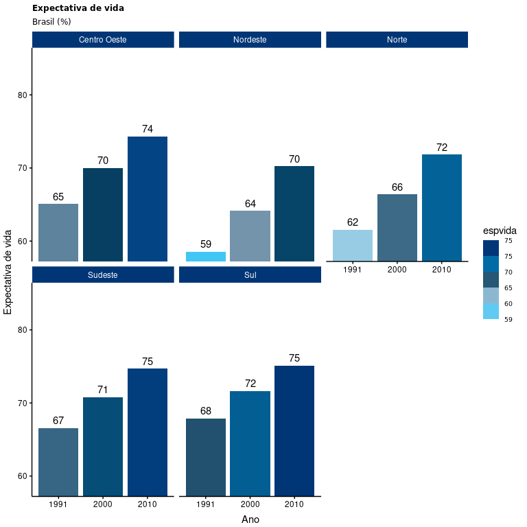

```r
# Option 2 for facet title color
ggplot(data = graph, aes(x = as.character(ano), y = espvida, fill = espvida)) +
  # Create a bar plot with 'ano' on x-axis, 'espvida' on y-axis, and 'espvida' for fill
  geom_bar(stat = "identity") +
  # Set the x-axis label
  xlab('Ano') +
  # Set the y-axis label
  ylab('Expectativa de vida') +
  # Add value labels to the plot
  insert_text(label = "espvida", decimals = 0) +
  # Create separate panels for each 'regn'
  facet_wrap(. ~ regn) +
  # Format y-axis labels
  scale_y_continuous(labels = scales::label_comma(decimal.mark = ",", big.mark = ".")) +
  # Set the plot title and subtitle
  ggtitle(label = "Expectativa de vida", subtitle = "Brasil (%)") +
  # Apply the default IPEA theme
  theme_ipea() +
  # Apply the IPEA continuous fill color scale
  scale_fill_continuous_ipea() +
  # Set the y-axis limits
  coord_cartesian(ylim = c(min(graph$espvida), max(graph$espvida) + 10))
```

## Thematic maps

The next step is to combine the *templatesIpea* package with other data sets to create thematic maps. In this example, we will be using data from the (Atlas of Human Development (by Ipea/FJP and UNPD) to create a choropleth map using geobr package showing the spatial variation of Average years of study across Brazilian municipalities.

#### Merge external data

```r
# Load municipality and state spatial data
mun = geobr::read_municipality()
uf  = geobr::read_state()

# Subset and select specific columns from the 'pnud_muni' dataset
pnud = abjData::pnud_muni %>%
  # Susbet data
  subset(ano == 2010) %>%
  # Select columns
  select(ano, code_muni = codmun7, e_anosestudo, rdpc)

# Perform a left join between the 'mun' and 'pnud' data frames
df = left_join(mun, pnud)
```

#### Plot thematic map

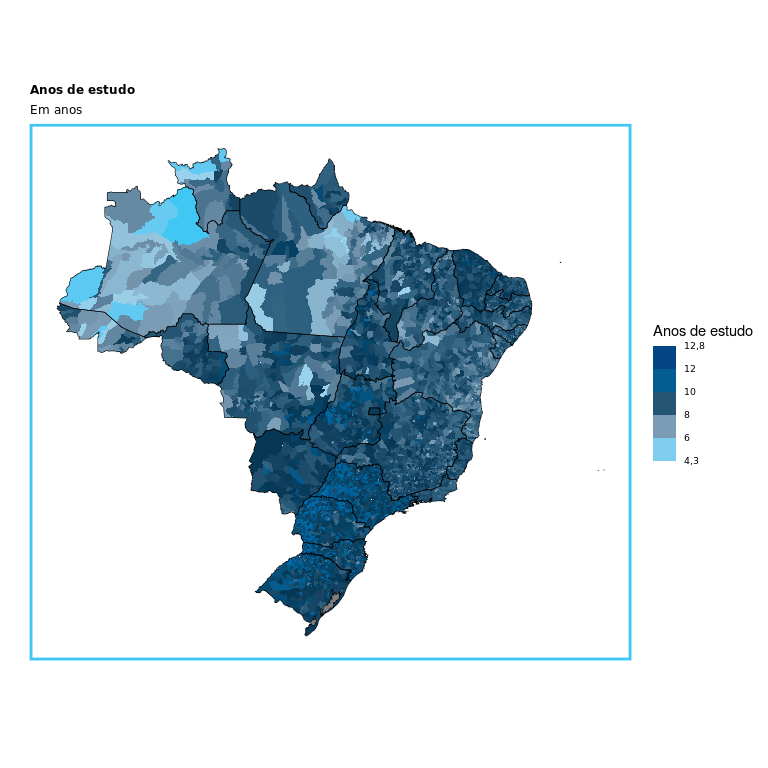

```r
# Create a ggplot object 'graf2' using the 'df' dataset, mapping the 'e_anosestudo' variable to the fill aesthetic
graf2 <- ggplot(data = df, aes(fill = e_anosestudo)) +

  # Add a layer of spatial polygons without borders (color = NA)
  geom_sf(color = NA) +

  # Add a layer of state boundaries from the 'uf' dataset, with black borders and no fill
  geom_sf(data = uf, color = "black", fill = NA) +

  # Set the main title and subtitle of the plot
  ggtitle("Anos de estudo", "Em anos") +

  # Remove the x-axis and y-axis labels
  xlab("") + ylab("") +

  # Apply the IPEA theme with full axes and without text elements
  theme_ipea(axis = "full", text = F) +

  # Apply the IPEA continuous fill scale to the 'e_anosestudo' variable,
  # showing the scale limits and providing a custom name for the legend
  scale_fill_continuous_ipea(show.limits = T, name = "Anos de estudo")

graf2
```